# Welcome to the Tidyverse

NB: i colori vengono assegnati da ggplot non siamo noi a controllarli! Ovvero, se scrivessi `aes(colour = "red")` ggplot non disegnerebbe l’elemento in rosso, ma “red” verrebbe considerata come una categoria a cui ggplot assegnerà un colore secondo la sua palette! C’è un modo per assegnare manulamente i colori? Sì, ma è un po’ complesso. In compenso il pacchetto `ggplot2` e la sua estensione `ggthemes` hanno diverse funzioni `scale_colour_` che ci consentono di utilizzare palette diverse. Ad esempio, costruiamo il grafico precedente modificando la palette di colori:

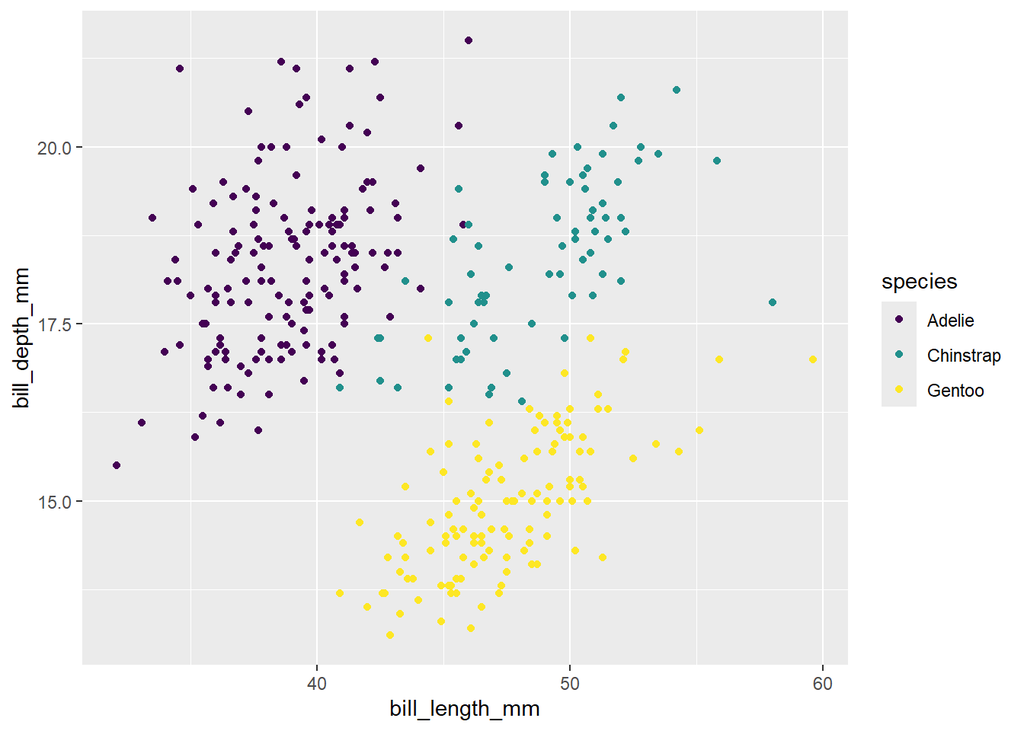

```r
penguins %>%
  # passo alla funzione ggplot il dataframe. La funzione ggplot prende come primo argomento data.
  ggplot(
    mapping = aes(x = bill_length_mm,
                  y = bill_depth_mm,
                  colour = species  # colora in base alla specie
                  )) +
  geom_point() +
  scale_colour_viridis_d()
```

gli elementi `geom_` hanno in realtà la possibilità di subire modifiche nell’apparenza, ma queste devono essere dentro le parentesi ma fuori da `aes()`. NB: queste modifiche potrebbero non essere poi riportate in legenda, quindi bisogna fare attenzione.

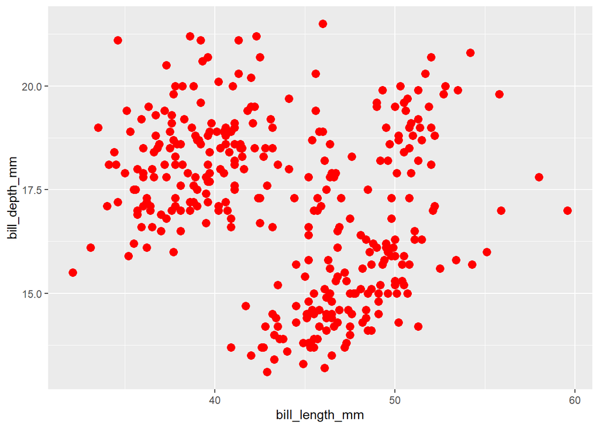

```r
penguins %>%
  # passo alla funzione ggplot il dataframe. La funzione ggplot prende come primo argomento data.
  ggplot(
    mapping = aes(x = bill_length_mm,
                  y = bill_depth_mm,
                  colour = species  # colora in base alla specie
                  )) +
  # anche se gli ho detto di colorare in base alla specie, fornendo il colore a geom_ l'aes è stata sovrascritta
  geom_point( col = "red", size = 3)
```

Se invece di usare una variabile categorica nel colore usiamo una variabile continua i punti verranno colorati secondo ua scala di colori:

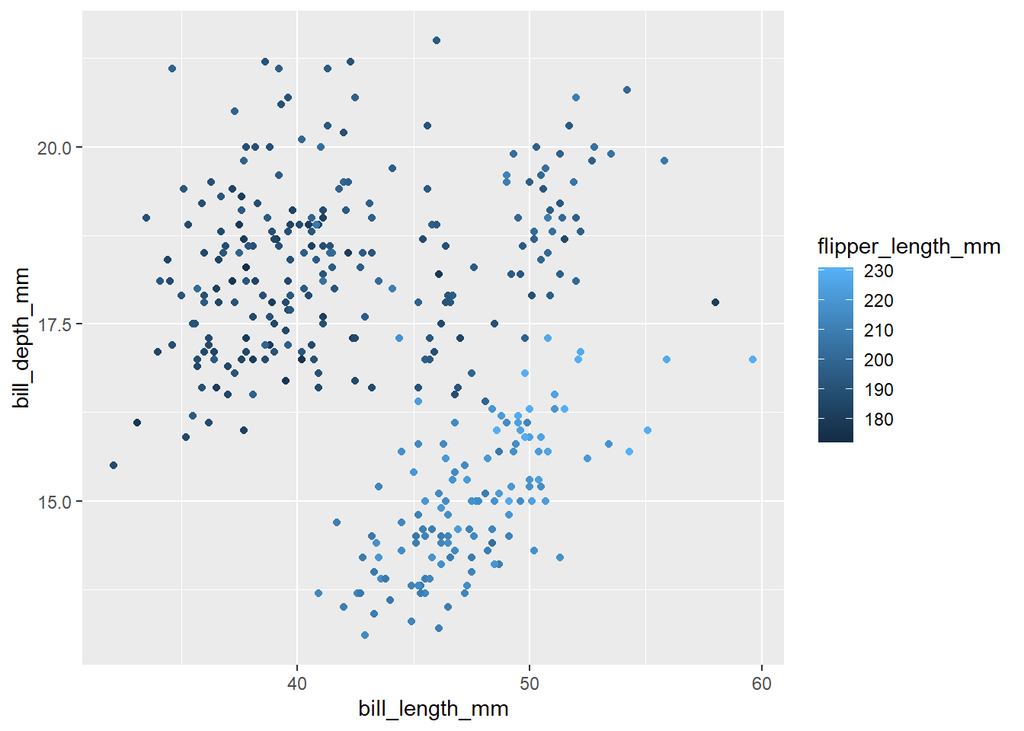

```r
penguins %>%
  # passo alla funzione ggplot il dataframe. La funzione ggplot prende come primo argomento data.
  ggplot(
    mapping = aes(x = bill_length_mm,
                  y = bill_depth_mm,
                  colour = flipper_length_mm  # colora in base alla flipper length
                  )) +
  geom_point()
```

E se assegnamo anche la shape la legenda e i punti verranno costruiti di conseguenza:

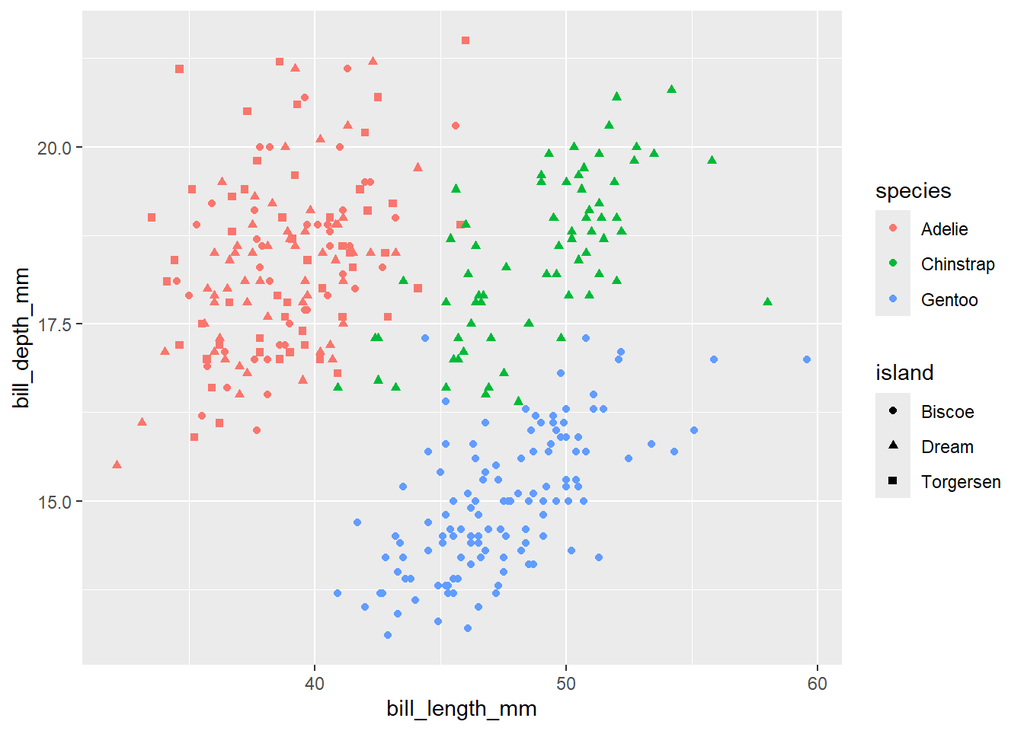

```r
penguins %>%
  # passo alla funzione ggplot il dataframe. La funzione ggplot prende come primo argomento data.
  ggplot(
    mapping = aes(x = bill_length_mm,
                  y = bill_depth_mm,
                  colour = species,  # colora in base alla specie
                  pch = island
                  )) +
  geom_point()
```

Assegnare il colore, la size o pch con variabili categoriche è utile con la funzione geom_smooth(method = “lm”) perché consente di costruire contemporaneamente più rette con poche righe di codice:

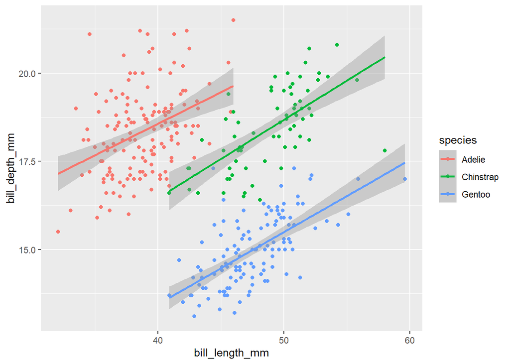

```r
penguins %>%
  # passo alla funzione ggplot il dataframe. La funzione ggplot prende come primo argomento data.
  ggplot(
    mapping = aes(x = bill_length_mm,
                  y = bill_depth_mm,
                  colour = species  # colora in base alla specie
                  )) +
  geom_point() + geom_smooth(method = "lm")
```

come vedete la funzione `geom_smooth()` ha agito in base al colore.

Per estendere le rette si può assegnare `fullrange = TRUE` e per rimuovere le bande dell’errore `se = FALSE`:

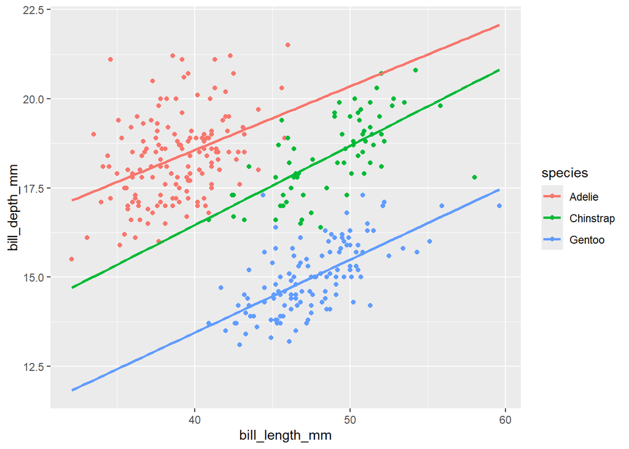

```r
penguins %>%
  # passo alla funzione ggplot il dataframe. La funzione ggplot prende come primo argomento data.
  ggplot(
    mapping = aes(x = bill_length_mm,
                  y = bill_depth_mm,
                  colour = species  # colora in base alla specie
                  )) +
  geom_point() + geom_smooth(method = "lm", se = FALSE, fullrange = TRUE)
```

Se volessi disegnare le rette per ogni colore e una retta con tutti i punti dovrei aggiungere due geom_smooth e in una rimuovere il colore o assegnare una nuova categoria di colore:

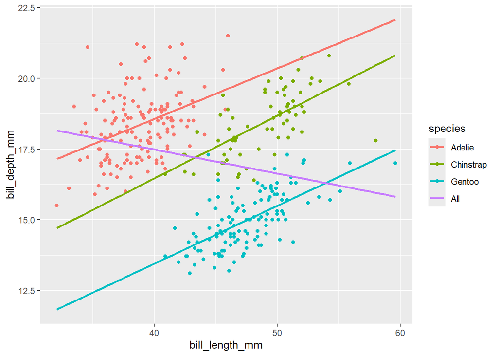

```r
penguins %>%
  # passo alla funzione ggplot il dataframe. La funzione ggplot prende come primo argomento data.
  ggplot(
    mapping = aes(x = bill_length_mm,
                  y = bill_depth_mm,
                  colour = species  # colora in base alla specie
                  )) +
  geom_point() +
  geom_smooth(method = "lm", se = FALSE, fullrange = TRUE) + # rette in base alla specie
  geom_smooth(
    mapping = aes(colour = "All"), # modifico il mapping per questa funzione: adesso tutti i punti
                                   # o le linee disegnate apparterranno al colore "All"
    method = "lm", se = FALSE, fullrange = TRUE)
```

la retta globale quì è disegnata in viola.

### Variabili categoriche vs variabili continue: geom_boxplot(), geom_violin(), geom_jitter()

Posso costruire anche grafici con variabili categoriche nelle ascisse e continute nelle ordinete, utilizzando le funzioni `geom_boxplot()`, `geom_violin()` o `geom_jitter()`. Quest’ultima costruisce un grafico a dispersione con un rumore casuale nei valori, regolabile con le variabili width e height:

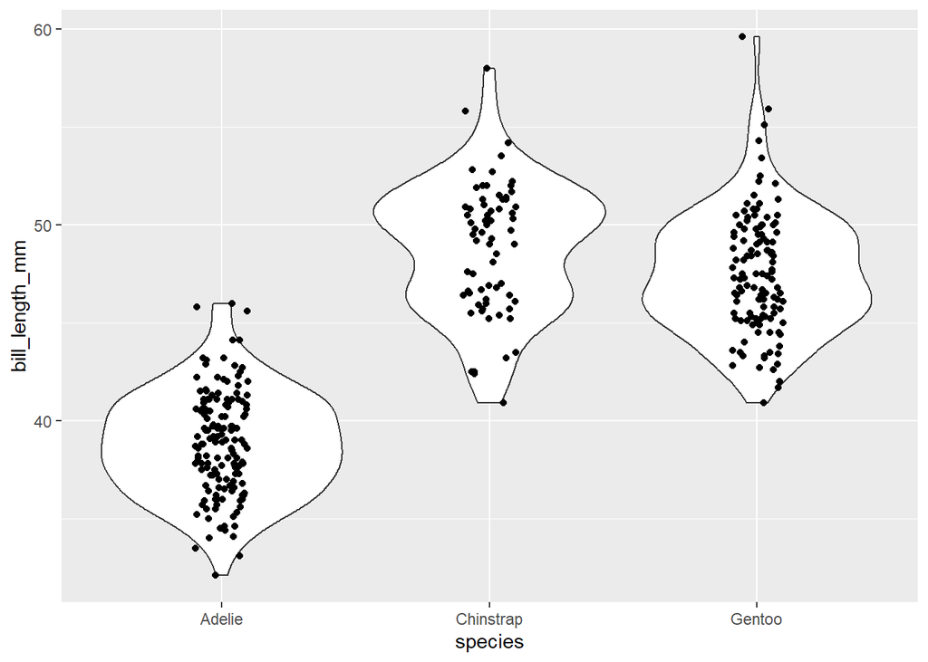

```r
penguins %>%
  ggplot(aes(x = species, y = bill_length_mm)) +
  geom_violin() + geom_jitter(width = 0.1, height = 0) # disegno sia  i punti che il violin
```

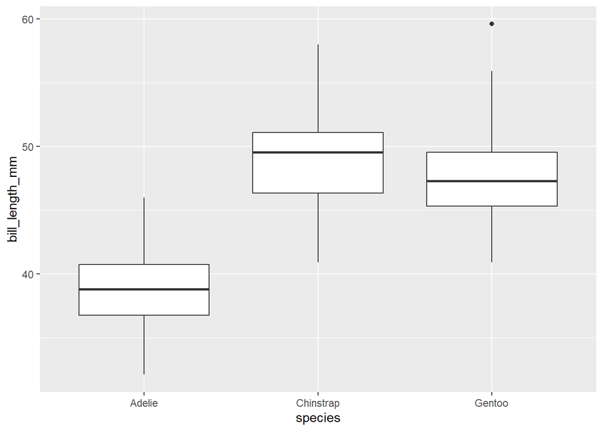

```r
penguins %>%
  ggplot(aes(x = species, y = bill_length_mm)) +
  geom_boxplot()
```

### Solo variabili continue: geom_histogram(), geom_density()

Posso anche costruire grafici con una sola variabile continua come istogrammi o density plot:

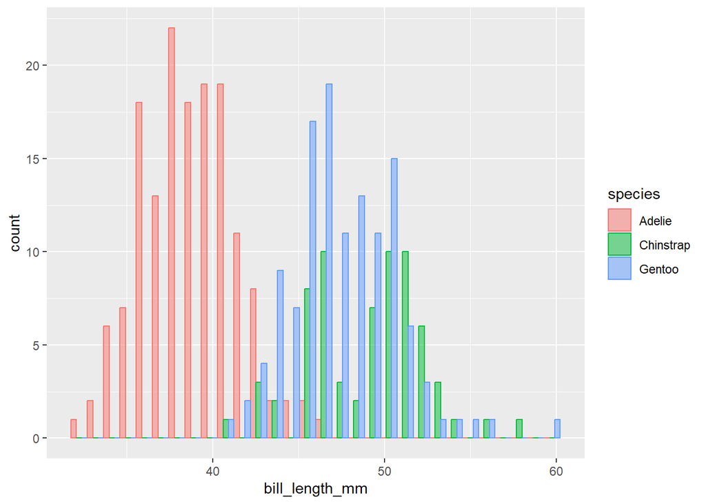

```r
penguins %>%
  ggplot(aes(x = bill_length_mm,
             fill = species, # colore interno
             colour = species # colore del bordo
             )) +
  geom_histogram(
    position = position_dodge(), # fa in modo che le colonne non si sovrappongano; utile con più colori
    alpha = 0.5 # assegno il valore di trasparenza a 0.5
                 )
```

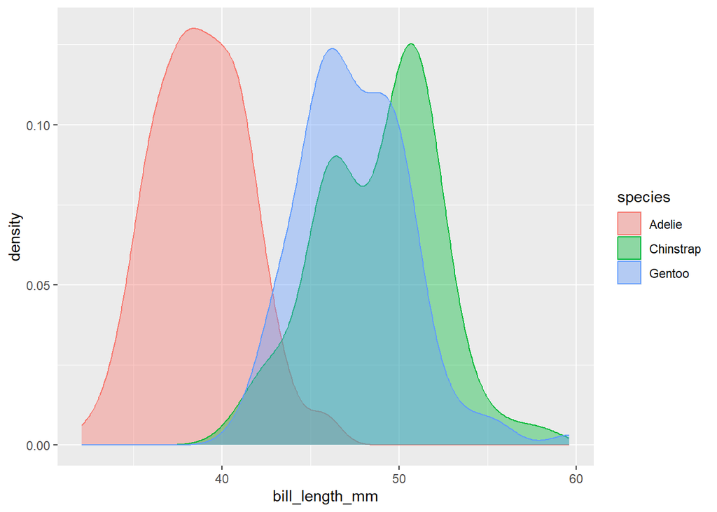

```r
penguins %>%
  ggplot(aes(x = bill_length_mm,
             fill = species, # colore interno
             colour = species # colore del bordo
             )) + geom_density(alpha = 0.4 # assegno il valore di trasparenza a 0.4
                               )
```